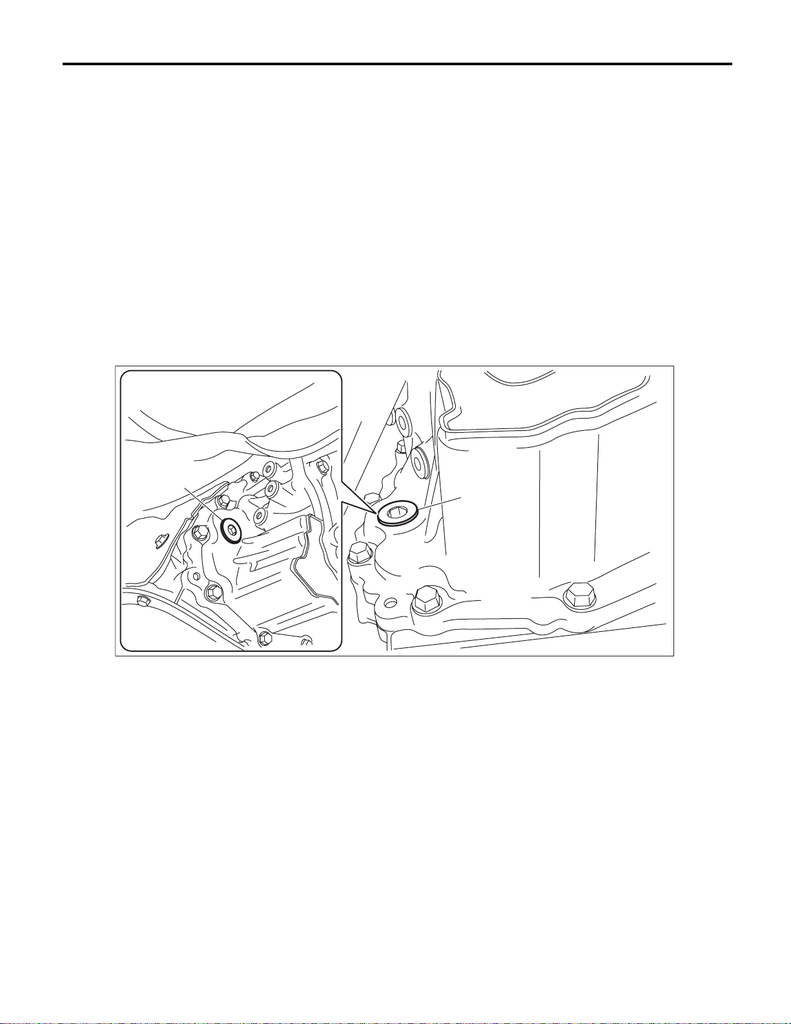

CVT(TR690)-36

CVTF

CONTINUOUSLY VARIABLE TRANSMISSION

2. CVTF

A: INSPECTION

Check for leakage of CVTF from transmission.

B: ADJUSTMENT

CAUTION:

• CVTF level changes along with CVTF temperature. When inspecting CVTF level, observe the spec-

ified CVTF temperature.

• Always use specified CVTF. Using other fluid will cause malfunction.

1) Idle the engine to raise CVTF temperature to 35 — 45°C (95 — 113°F) on Subaru Select Monitor.

2) Operate the select lever in P → R → N → D and D → N → R → P to circulate CVTF with the engine idling.

3) With the engine running, lift up the vehicle and remove the filler plug.

CAUTION:

Pay special attention to the following operations as the engine is at idle.

NOTE:

CVTF is at the specified level when it is up to the filler plug hole lower section.

(A) Filler plug

(A)

(A)

AT-07748

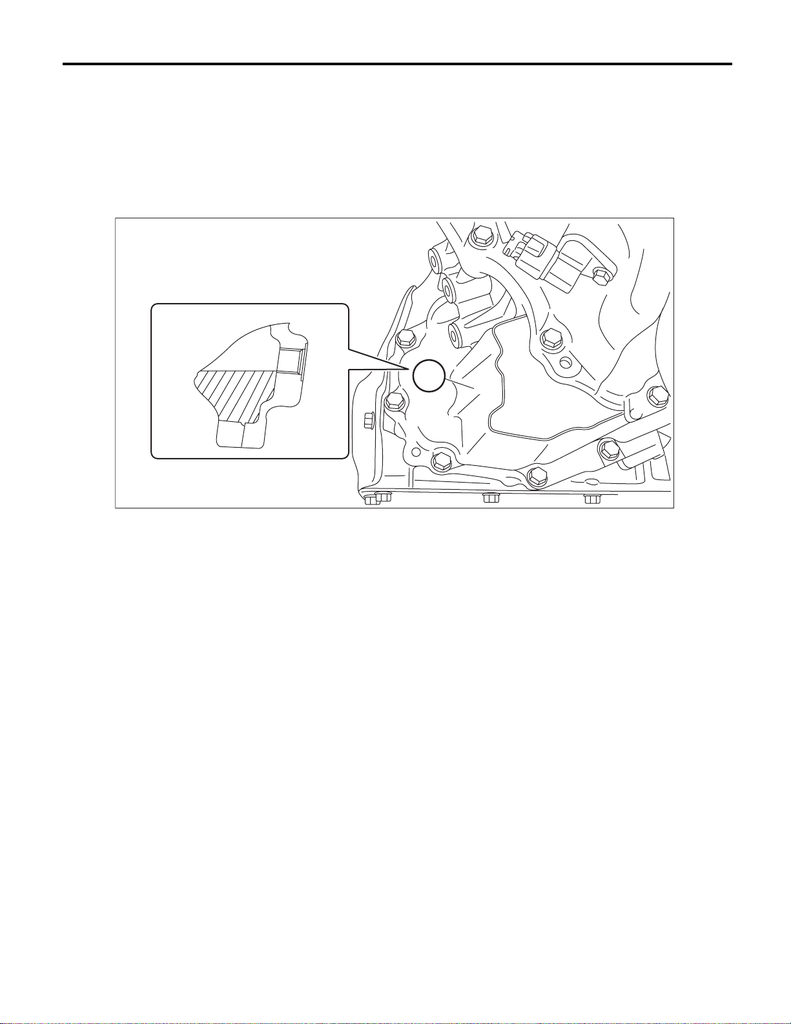

CVT(TR690)-37

CVTF

CONTINUOUSLY VARIABLE TRANSMISSION

4) When there is no CVTF leakage from the transmission, add the specified fluid up to the filler plug hole low-

er section.

Specified fluid:

<Ref. to CVT(TR690)-4, HYDRAULIC CONTROL AND LUBRICATION, SPECIFICATION, General De-

scription.>

CAUTION:

Note that when CVTF is added up to the lower section of filler plug while the transmission is in cold

condition, overfilling of CVTF occurs, causing the oil to spill out.

5) Install the filler plug.

NOTE:

Use a new gasket.

Tightening torque:

50 N·m (5.1 kgf-m, 36.9 ft-lb)

(A) Filler plug hole

(A)

(A)

AT-07749

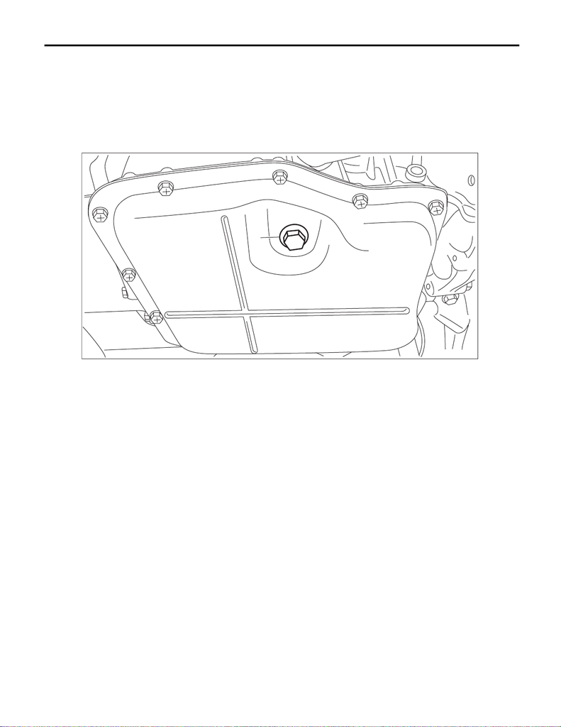

CVT(TR690)-38

CVTF

CONTINUOUSLY VARIABLE TRANSMISSION

C: REPLACEMENT

CAUTION:

• Directly after the vehicle has been running or the engine has been idling for a long time, the CVTF

is hot. Be careful not to burn yourself.

• Be careful not to spill the CVTF on exhaust pipe to prevent it from emitting smoke or causing fires.

If CVTF adheres, wipe it off completely.

• Always use specified CVTF. Using other fluid will cause malfunction.

1) Lift up the vehicle, and remove the CVTF drain plug.

2) Check the CVTF condition. <Ref. to CVT(TR690)-40, CONDITION CHECK, CVTF.>

3) Install the CVTF drain plug and gasket.

NOTE:

• Use a new gasket.

Tightening torque:

39.2 N·m (4.0 kgf-m, 28.9 ft-lb)

(A) CVTF drain plug

(A)

AT-07750

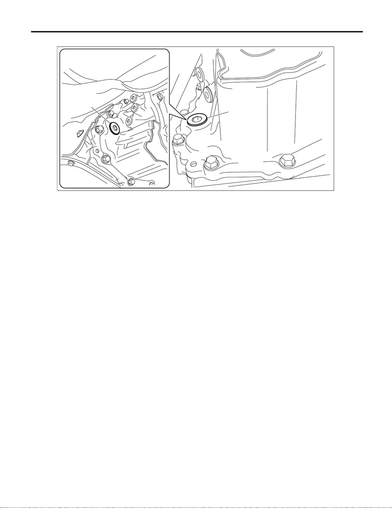

CVT(TR690)-39

CVTF

CONTINUOUSLY VARIABLE TRANSMISSION

4) Remove the filler plug.

5) Fill in the specified fluid through the filler plug.

Specified fluid:

<Ref. to CVT(TR690)-4, HYDRAULIC CONTROL AND LUBRICATION, SPECIFICATION, General De-

scription.>

Capacity:

Fill with the same amount of CVTF as drained.

6) Temporarily tighten the filler plug.

7) Idle the engine to raise CVTF temperature to 35 — 45°C (95 — 113°F) on Subaru Select Monitor.

8) Operate the select lever in P → R → N → D and D → N → R → P to circulate CVTF with the engine idling.

CAUTION:

Pay special attention to the following operations as the engine is at idle.

9) Place the select lever in “P” range. Then lift up the vehicle with the engine at idle to adjust the CVTF level

and check for leakage. <Ref. to CVT(TR690)-36, ADJUSTMENT, CVTF.>

(A) Filler plug

(A)

(A)

AT-07748

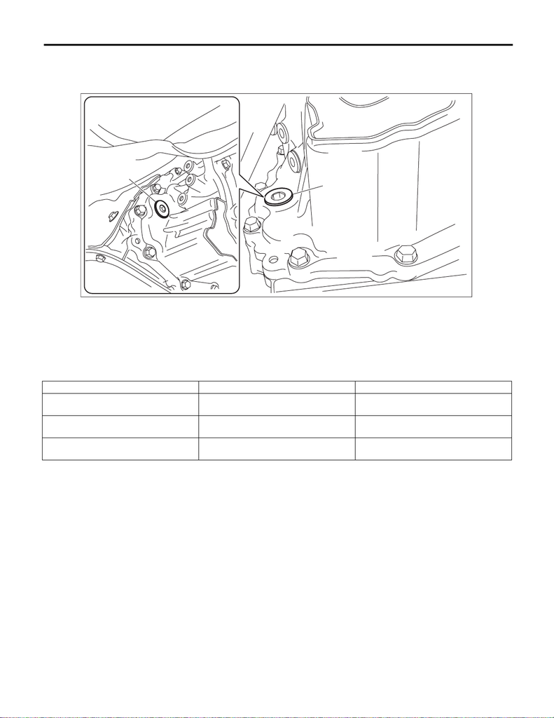

CVT(TR690)-40

CVTF

CONTINUOUSLY VARIABLE TRANSMISSION

10) Replace with a new gasket, and attach the filler plug.

Tightening torque:

50 N·m (5.1 kgf-m, 36.9 ft-lb)

D: CONDITION CHECK

NOTE:

When replacing CVTF, determine the condition inside the transmission body by inspecting the drained

CVTF.

(A) Filler plug

Fluid condition Trouble and possible cause Corrective action

Metal particles. Excessive wear of the internal of the

transmission body.

Replace CVTF and check if CVT oper-

ates correctly.

Thick and varnish-form fluid. Burnt clutches Replace CVTF and check the CVT body

or vehicle for faulty.

Clouded CVTF or bubbles. Water mixed in fluid. Replace CVTF and check the water

entering point.

(A)

(A)

AT-07748